# MLE for glm

Taotao

10/26/2020

### Simulate 6 data point, with two groups.

The population parameter $\beta_0 = 1, \beta_1 = 1.5$

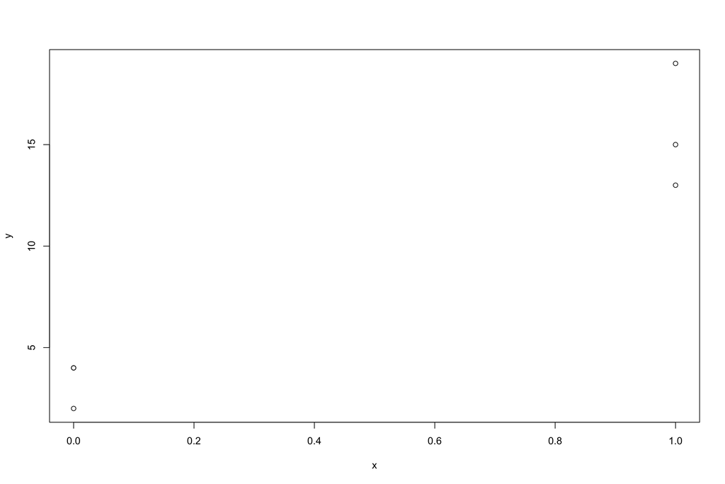

```r
x = c(rep(0, 3), rep(1, 3))
y = c()
b0 = 1
b1 = 1.5

for (i in 1:length(x)){
  y[i] <- rpois(1,exp(b1 * x[i] + b0))
}

plot(x, y)
```

```r
cbind(x, y)
```

```
##      x  y
## [1,] 0  2
## [2,] 0  4
## [3,] 0  4
## [4,] 1 19
## [5,] 1 15
## [6,] 1 13
```

### Use MLE to build the model

We need to estimate $\beta_0, \beta_1$. The assumption is that $Y \sim Poisson(e^{\beta_0 + \beta_1x})$

We have the $pmf = \frac{\lambda ^k e^{-k}}{k!}$, where lambda is a parameter (mean of the population) and k is a random variable.

So have the log likelihood of a single point is$ll = log[pmf] = k(b_0 + b_1x) - exp(b_0 + b_1x) - log(k!)$. Plug y into k, and plug x into x, and sum up all data.

```r
ll <- function (z){
  b0 <- z[1]
  b1 <- z[2]

  return(-(
    y[1]*(b0 + b1*x[1]) - exp(b0 + b1*x[1]) - log(factorial(y[1])) +
    y[2]*(b0 + b1*x[2]) - exp(b0 + b1*x[2]) - log(factorial(y[2])) +
    y[3]*(b0 + b1*x[3]) - exp(b0 + b1*x[3]) - log(factorial(y[3])) +
    y[4]*(b0 + b1*x[4]) - exp(b0 + b1*x[4]) - log(factorial(y[4])) +
    y[5]*(b0 + b1*x[5]) - exp(b0 + b1*x[5]) - log(factorial(y[5])) +
    y[6]*(b0 + b1*x[6]) - exp(b0 + b1*x[6]) - log(factorial(y[6]))))
}

# here is the optimal parameter
res = optim(c(1,1), ll)

# estimated parameters
# the population parameter is b0 = 1, b1 = 1.5, which is close to the estimated parameters
res$par
```

```
## [1] 1.204007 1.547446
```

```r
# log likelihood
-res$value
```

```
## [1] -12.47869
```

### validate with glm function; notice the coefficient is the same.

```r
glm(y ~ x, family = poisson(link = "log"))
```

```
##
## Call:  glm(formula = y ~ x, family = poisson(link = "log"))
##
## Coefficients:
## (Intercept)            x
##       1.204        1.548
##
## Degrees of Freedom: 5 Total (i.e. Null);  4 Residual
## Null Deviance:       28.12
## Residual Deviance: 2.048     AIC: 28.96
```

Note: The selection of distribution and link function is somewhat arbitrary. For example, I can also use negative binomial as the distribution. If that is the case, I will need to estimate one more parameter: dispersion. But the framework is the same. Conclusion: carefully select model and link function.

### Manually calculate the p value with likelihood ratio test.

Here we want to test if $\hat \beta_1$ is statistically significant. We will perform a likelihood ratio test.

We have already calculated the $log (likelihood)_{max}$ = -optim(c(1,1), ll)$value. Let’s build another model where we only have one variable. Again, we will use MLE.

Here $ll_{null} = log[pmf] = k(b_0) - exp(b_0) - log(k!)$

```r
ll_null <- function (z){
  b0 <- z[1]

  return(-(
    y[1]*(b0) - exp(b0) - log(factorial(y[1])) +
    y[2]*(b0) - exp(b0) - log(factorial(y[2])) +
    y[3]*(b0) - exp(b0) - log(factorial(y[3])) +
    y[4]*(b0) - exp(b0) - log(factorial(y[4])) +
    y[5]*(b0) - exp(b0) - log(factorial(y[5])) +
    y[6]*(b0) - exp(b0) - log(factorial(y[6]))))
}


null_res = optim(c(1), ll_null)

# estimated parameter
null_res$par
```

```
## [1] 2.251367
```

```r
# log likelihood
-null_res$value
```

```
## [1] -25.51694
```

The formula to calculate the likelihood ratio test is $\lambda = -2[l_{null} - l_{max}]$, where $\lambda$ is chi square distributed with 1 degree of freedom (2 parameters - 1 parameter = 1 df). Then we use pchisq to calculate the area under the curve

```r
chi = -2 * (-null_res$value - (-res$value))

1 - pchisq(chi, df =1)
```

```
## [1] 3.28152e-07
```

## Validate the result with lrtest function. Notice the p value is the same

summary() calculate a z score for the glm model, which I don’t think make too much sense. But the p value is not significantly different from each other (likelihood ratio test vs z test).

```r
library(lmtest)
model_null = glm(y~1, poisson(link = "log"))
model = glm(y~x,poisson(link = "log"))

lrtest(model_null,model)
```

```
## Likelihood ratio test
##
## Model 1: y ~ 1
## Model 2: y ~ x
##   #Df  LogLik Df  Chisq Pr(>Chisq)
## 1   1 -25.517
## 2   2 -12.479  1 26.076  3.282e-07 ***
## ---
## Signif. codes:  0 '***' 0.001 '**' 0.01 '*' 0.05 '.' 0.1 ' ' 1
```

I don’t think z test make sense for glm.

```r
summary(model)$coefficients
```

```
##             Estimate Std. Error  z value     Pr(>|z|)
## (Intercept) 1.203973  0.3162277 3.807297 1.404940e-04
## x           1.547563  0.3482478 4.443854 8.836165e-06
```